# Studying SNAP retailers during the Great Recession

Jerry Shannon

June 29, 2018

This paper provides a research rationale and methodology for a dataset of SNAP retailers from 2008-2017, available through [this Github repository](https://github.com/jshannon75/snap_retailers_2008_2017).

## Background

Research on geographic access to healthy food outlets dates to the early 2000s. A group of British researchers first used the term *food desert* to describe neighborhoods without access to healthy and affordable food, basing it on an interview with neighborhood residents (Cummins and Macintyre 1999; Wrigley 2002). This term and its emphasis on the influence of neighborhood food environments quickly gained traction. A 2017 review, for instance, identified 432 articles measuring food environments (Lytle and Sokol 2017). Of those, 65% used geographic analysis–making use of geographic information systems (GIS) to measure proximity to varying store types such as supermarkets and convenience stores. In the United States, the 2008 Farm Bill mandated a national analysis of food accessibility (Walker, Keane, and Burke 2010). The Food Access Research Atlas is one result of this mandate, providing a widely used map of what it terms “low income, low access” census tracts where supermarkets are distant (USDA Economic Research Service 2014). The federal Healthy Food Financing Initiative is an example of policies developed based on these maps to improve food access. This program targets food deserts specifically, providing both public and private money for new stores or redevelopment of existing sites (Office of Community Services 2011).

Despite the popularity of food deserts as a metaphor, both the term and the geographic methodology have been criticized in recent years. While “desert” conjures up the image of places where food is simply unavailable, neighborhoods identified as food deserts often have abundant sources of largely processed, nutrient poor foods: fast food and corner stores, for example. As an alternative, some have suggested that the term *food swamp* more accurately describes these areas (Cooksey-Stowers, Schwartz, and Brownell 2017; Fielding and Simon 2011). While geographic analysis has identified multiple neighborhoods with poor access to supermarkets, policies that spur the creation of new stores have shown little if no impact on the dietary quality of nearby residents (Ghosh-Dastidar et al. 2017). Most geographic analyses also focus on the potential role of the residential food environment, and only recently has research begun to incorporate the mobility of individuals and the ways they navigate the food options available to them throughout the day (Widener and Shannon 2014; Chrisinger et al. 2018; Li and Kim 2017). This work highlights the ways that low-income households do access food sources outside their residential neighborhoods, especially for lower prices or better perceived food quality (Shannon 2016). At the same time, this mobility may also often entail high time or economic costs and rely on extended social networks.

In addition to these critiques, ecological metaphors for food accessibility–whether deserts or swamps–deserve scrutiny. These terms implicitly rely on a free market model, describing neighborhood food environments as natural features that emerge as part of open economic activity. They also focus attention on low-access neighborhoods as aberrations in an otherwise healthy and habitable landscape, areas that just need remediation (Shannon 2014). Yet a parallel line of research on food justice suggests that food deserts are by no means natural (Alkon and Agyeman 2011). Rather, they are part of larger racialized inequalities inherent to both urban development and industrialized food production (McClintock 2011). In this sense, terms like supermarket redlining (Eisenhauer 2001; Zhang and Ghosh 2016) or food apartheid (Brones 2018) may better describe the processes at play. Indeed, real estate redlining was a driving force for suburbanization for much of the 20th century (Jackson 1987) and supermarkets as a model emerged alongside these booming suburban communities. Studying the distribution of food retailers, therefore, reveals the ways that their location has been shaped by policies across geographic scales. It questions language that frames food environments as shaped primarily by the workings of the free market, focusing instead on the ways racial and economic inequality are implicitly and explicitly hardwired into the food system. In doing so, this approach highlights the need for systemic change rather than locally targeted policies.

The Supplemental Nutrition Assistance Program (SNAP, formerly known as food stamps) is one key systemic policy mechanism that shapes local food environments. The food stamp program originated in the Great Depression. Originally a direct commodity surplus distribution program designed to support struggling farmers, the program was revised to include the growing supermarket industry, providing vouchers redeemable for food purchases (Moran 2011). Revived during the Kennedy administration in the 1960s, the food stamp program has proven to be one of the most durable income support programs over the last fifty years, outlasting other programs such as Aid for Families with Dependent Children (AFDC) that were heavily curtailed during welfare reform in the 1990s (Gritter and MacRobert 2015). Supporters point to both its economic stimulus and effectiveness at lowering rates of food insecurity among vulnerable populations (Bartfeld et al. 2015).

In 2017, SNAP provided $63.6 billion dollars of financial assistance to over 42 million individuals nationwide (U.S. Dept. of Agriculture 2018). SNAP benefits–currently delivered electronically and redeemable through a electronic card similar to credit cards–can be redeemed at authorized retailers for a wide range of food items. In contrast to direct relief for working families, such as commodity surplus distribution, SNAP works in coordination with private markets, providing benefits to producers, distributors, and retailers in addition to low-income households (Hanson 2010). The spatial effect of SNAP’s economic stimulus has rarely been analyzed. In times of economic hardship, such as the Great Recession of 2008, SNAP may provide counter-cyclical economic support not just for low-income households, but also for retailers. This period thus offers the chance to understand how SNAP may shape local food environments–providing economic support for certain types of food retailers. In this sense, SNAP as a policy actively shapes the landscape of foods available to consumers.

As noted above, recent research on food access has focused on the mobility of individuals, asking how and where individuals interact with the food system (Shannon 2016, Widener and Shannon (2014)). This research provides valuable insight on how access to transit, cultural preferences, store perceptions, and reliance on social networks matter to everyday food provisioning patterns. Focusing on the shifting landscape of SNAP retailers provides a parallel line of research, one that focuses on the *mobility of food retailers*, their responses to shifting policy environments andto shifting demographic and development patterns. This mobility reveals the patterns of capital investment by food retailers, underscoring how some neighborhoods may be effectively redlined based on racial or economic characteristics. Because it works through market based mechanisms, SNAP interacts with these processes, providing signifciant economic incentive for retailers, even if the effects of this incentive may be uneven. For example, previous research in Georgia has found that higher SNAP enrollment fueled significant growth among small retailers in the years after the recession, but had little effect for large retailers (Shannon et al. 2018).

This longitudinal, national dataset contains data on the location of SNAP retailers each June from 2008 through 2017. Through analyses of these data, future research can better articulate how increased participation in SNAP impacted the geography of SNAP retailers. While most large stores participate in SNAP, participation is less consistent for small retailers. Our previous research indicated that roughly half the stores entering SNAP during this time frame were present prior to the recession (Shannon et al. 2018). As a result, these data provide the best insight into how some retailers relied on the financial stimulus provided during this period and the potentially disparate effects of this shifting landscape on the food sources available to SNAP clients. It reveals how SNAP may have ameliorated or enhanced existing retailer redlining in communities across the country. Lastly, it provides a resource for more in depth local research on food quality and selection within stores or interactions between retailers and local residents.

## Methods and data characteristics

These store data were obtained through direct email contact with the USDA Benefit Redemption Division. In response to a records request, the agency sent a CD with retailer listings on June 30 for the years 2008 through 2017. These were provided as separate Excel files. To combine them, I used [this R script](https://github.com/jshannon75/snap_retailers_2008_2017/raw/master/snap_csvcombine.R). This file reads in each Excel file, adds a year column, and then combines them into a single listing. Entries with identical names and addresses are identified by shifting the year column from “long” to “wide” format. I then added a unique store ID for each line, as USDA does not provide their identifier when releasing public data.

Some retailers may have their names or addresses shift slightly from year to year–“B & H Foods”, for example, could become “B&H foods.” Fuzzy record matching is typically used to address this issue, but for a dataset with over 400,000 records, this is computationally challenging. Zane Page, a student in computer science at UGA, created a Python script to efficiently complete this comparison ([link to code](https://github.com/jshannon75/snap_retailers_2008_2017/tree/master/data/python_matching)), and the most likely matches were reviewed manually. In the end, only 19 records were combined through fuzzy matching. The [resulting dataset](https://github.com/jshannon75/snap_retailers_2008_2017/raw/master/data/snap_retailers_usda.csv) lists 425,869 retailers.

USDA also only provides locational data (latitude and longitude) for current retailers (n=261,500). For the additional locations, I used a three step process to add coordinates. First, retailers without coordinates were geocoded using ESRI’s [world geocoding service](https://www.esri.com/en-us/arcgis/products/world-geocoder-for-arcgis). Of these results, I selected addresses with relatively poor accuracy for further geocoding, those with match types of postal codes, postal locations, extended street address, and street name only. These were geocoded with the [Google Maps API](https://developers.google.com/maps/documentation/geocoding/intro) using the ggmap package in R. I used any addresses provided by Google that had greater accuracy than those provided by ESRI. Lastly, all points were visually inspected and several–particularly in the Virgin Islands–were manually geocoded using Bing Maps. The data contains columns for the methods of geocoding (ESRI, Google, Manual, or USDA) and the match type were applicable. See the documentation for ESRI and Google linked above for more information about the match types.

In addition to these locational data, I have also provided [a separate file](https://github.com/jshannon75/snap_retailers_2008_2017/raw/master/data/snap_retailers_crosswalk.csv) with FIPS codes and other identifiers specific to each data point, the state, county, and tract FIPS codes and the metropolitan statistical area (if applicable). I have also included a tract FIPS code–“gisjn_tct”–that is compatible with data from the [National Historical GIS](https://www.nhgis.org) database at the University of Minnesota. These can be joined to the main store listing through the store identifier (storeid).

USDA provides 17 types of retail classification based on store characteristics. While this granularity can be useful, I have also created a set of six store classifications that can simplify analysis. The crosswalk for these store types is shown below.

| USDA classification | Store group |
| --- | --- |
| Bakery Specialty | Specialty |
| Combination Grocery/Other | Small retail |
| Convenience Store | Small retail |
| Delivery Route | Other store |
| Direct Marketing Farmer | Local foods |
| Farmers’ Market | Local foods |
| Fruits/Veg Specialty | Specialty |
| Large Grocery Store | Grocer |
| Meat/Poultry Specialty | Specialty |
| Medium Grocery Store | Grocer |
| Military Commissary | Other store |
| Non-profit Food Buying Co-op | Local foods |
| Seafood Specialty | Specialty |
| Small Grocery Store | Grocer |
| Super Store | Supermarket |
| Supermarket | Supermarket |
| Wholesaler | Supermarket |

The full variable descriptions for these data are available on a separate spreadsheet ([link](https://github.com/jshannon75/snap_retailers_2008_2017/raw/master/data/snap_retailers_metadata.csv)).

## Data summary

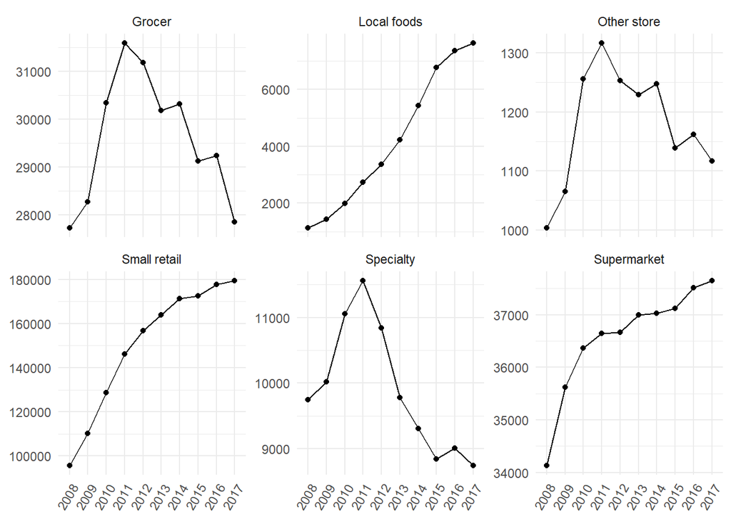

Count of retailers by year and store type

```r
store_counts<-stores %>%
  gather(Y2008:Y2017,key="year",value="count") %>%
  filter(count==1) %>%
  group_by(year,store_group) %>%
  summarise(count=n()) %>%
  mutate(year_n=substr(year,2,5)) %>%
  select(-year) %>%
  rename("Year"=year_n)

ggplot(store_counts,aes(x=Year, y=count, group=store_group)) +
  geom_point() +
  geom_line()+
  facet_wrap(~store_group,scales="free_y")+
  theme_minimal()+
  theme(axis.text.x = element_text(angle = 60, hjust = 1),
        axis.title=element_blank())
```

The figure below shows the normalized count of retailers by state/territory, which illustrates the consistency of these trends. The red line on these graphs represents a z score of 0, or the mean count across the time period in each area. Local foods and small retailers are both tightly clustered, following trends similar to those seen in the previous figure. Among small retailers, the only notable decrease is in the Virgin Islands, though both Guam and Washington, D.C. also saw drops in 2016 and 2017.

Among other store types, the trends are more diverse. Specialty retailers generally follow a downward trend in later years, similar to that seen the previous figure. However, some states including Colorado, Nevada, and Arizona saw notable increases toward the end of the study period. Supermarkets show a general upward trend in many states, but Nevada, Ohio, and Michigan are among the states where the number of supermarkets decreased across the time period. Lastly, among grocers, the trends vary widely across areas.

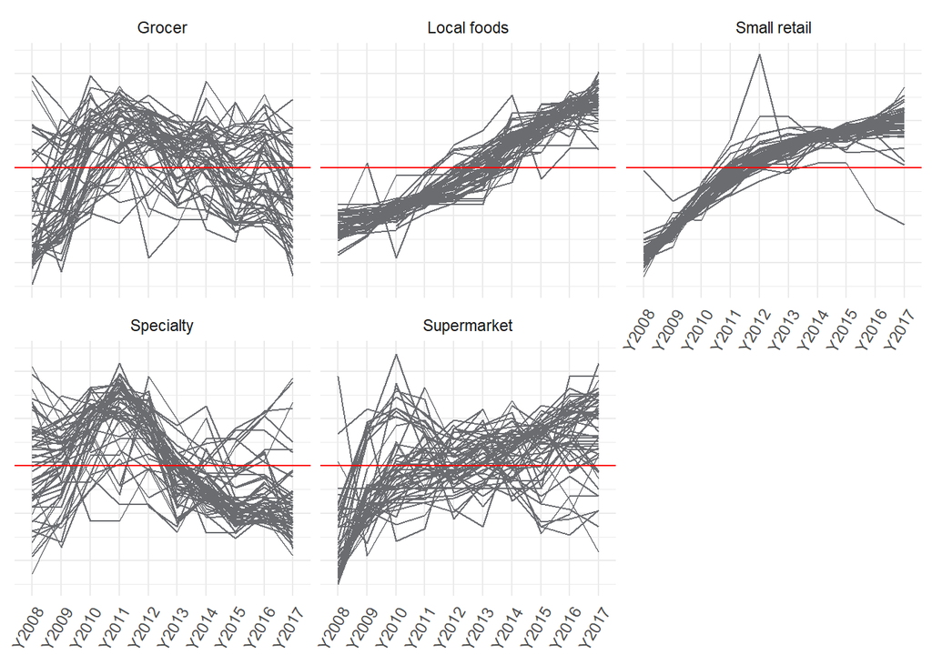

Yearly normalized count of retailers by state and store type

```r
store_counts_z<-stores %>%
  gather(Y2008:Y2017,key="year",value="count") %>%
  filter(count==1) %>%
  group_by(state,year,store_group) %>%
  filter(store_group %in% c("Supermarket","Grocer","Small retail","Specialty","Local foods")) %>%
  summarise(count=n()) %>%
  ungroup() %>%
  group_by(state,store_group) %>%
  mutate(count_mean=mean(count),
         count_sd=sd(count),
    count_z=((count-count_mean)/count_sd))


ggplot(store_counts_z,aes(x=year, y=count_z,group=state)) +
  geom_line(colour="#6a6c70") +
  geom_hline(colour="red",aes(yintercept=0))+
  facet_wrap(~store_group)+
  theme_minimal()+
  theme(axis.text.x = element_text(angle = 60, hjust = 1),
        axis.text.y = element_blank(),
        axis.title = element_blank())
```

The geographic data in this dataset make mapping the distribution of data a simple task using most GIS capable software (e.g., QGIS, R, ArcMap). The data contain fields for metropolitan statistical areas, and so stores can be easily subsetted by state, county, or urban region. For example, here are maps of each major store type in Chicago in 2008.

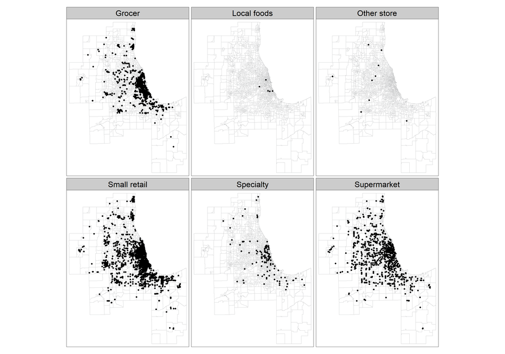

SNAP authorized retailers in Chicago, 2008

```r
stores_chi<-stores %>%
  filter(msa_fips==16980) %>%
  select(-Y2009:-Y2017) %>%
  gather(Y2008,key="year",value="present") %>%
  filter(present==1)

stores_chi_sf<-st_as_sf(stores_chi,coords=c("X","Y"),crs=4326)

tm_shape(layers_all) +
  tm_polygons(col="white",border.col="#bfc0c1",lwd=0.7)+
tm_shape(stores_chi_sf)+
  tm_dots(col="black",size=0.2) +
tm_facets(by="store_group",
          free.coords=FALSE) +
tm_layout(legend.title.size=3,
  legend.text.size =2,
  legend.bg.alpha = 1,
  panel.label.size = 2)
```

Using a basic Euclidean distance measure, I calculated the distance to the third closest authorized retailer in Chicago in 2008 and 2010. I measured the distance from each block centroid and then created a population weighted mean at the tract level–[see this script for distance calculation](https://github.com/jshannon75/snap_retailers_2008_2017/blob/master/StoreDistanceCalc_urban_2018_07_24_cloud.Rmd). The map below shows the change between those years. Areas in red or orange are those where distance to the third closest retailer increased during this time. Areas in green are those where distance to the third closest retailer decreased. I use the third closest retailer for this map because it provides a better measure of store density in an area and is less sensitive to the effects of a single store location.

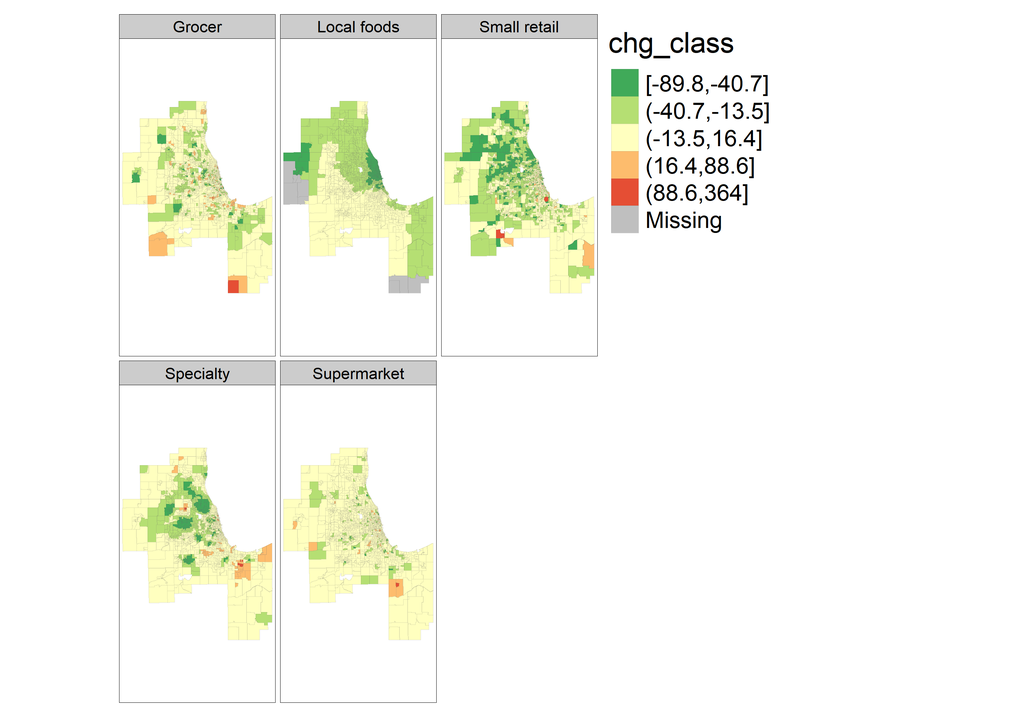

Change in distance to the third closest retailer in Chicago, 2008-2010

```r
layers_all_df<-layers_all
st_geometry(layers_all_df)<-NULL

classes <- classIntervals(layers_all_df$Y08_10_chg, n = 5, style = "jenks")
layers_all <- layers_all %>%
  mutate(chg_class = cut(Y08_10_chg, classes$brks, include.lowest = T))

tm_shape(layers_all) +
  tm_polygons("chg_class", palette = "seq", border.alpha=0.2)+
  tm_facets(by="store_group") +
  tm_layout(aes.palette = list(seq = "-RdYlGn"),
      legend.title.size=3,
      legend.text.size =2,
      legend.bg.alpha = 1,
      panel.label.size = 2)
```

```r
##Alternative--ggplot
# ggplot(layers_all) +
#   geom_sf(aes(fill=chg_class),lwd=.1) +
#   scale_fill_viridis_d() +
#   facet_wrap(~store_group)
```

The significant increases in SNAP retailers affected the overall makeup of retailers available within cities. While the number of supermarkets increased overall during this time period, they decreased as a percentage of all SNAP retailers during this time, primarily due to booming numbers of small retailers. The figure below shows supermarkets as a share of total retailers among the ten largest metro areas. Supermarkets as a share of retailers declined in each city. In Atlanta, they fell from 27% to 15% of all retailers, while in Detroit the decrease was from 14% to 10%.

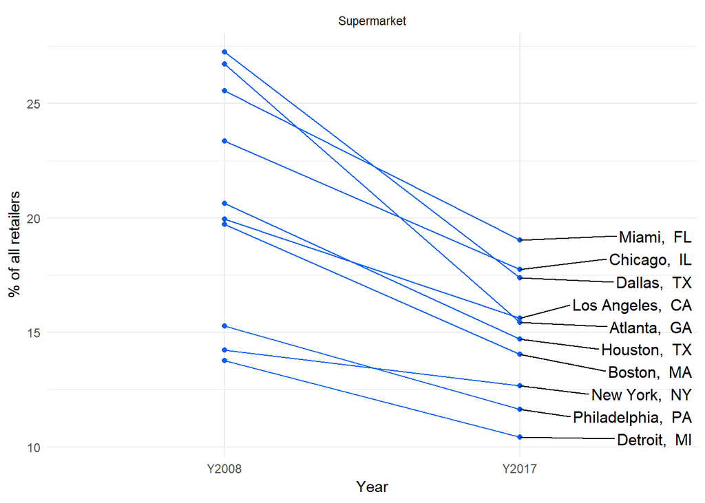

Supermarkets as a percentage of all SNAP retailers, 2008 and 2017

```r
msa_count<-stores %>%
  filter(msa_fips>0) %>%
  group_by(msa_name) %>%
  summarise(count=n()) %>%
  top_n(10,count)

stores_msa_chg<-stores %>%
  filter(msa_name %in% msa_count$msa_name) %>%
  gather(Y2008:Y2017,key="year",value="present") %>%
  filter(present==1) %>%
  group_by(msa_name,msa_short,store_group,year) %>%
  summarise(store_count=n()) %>%
  ungroup() %>%
  group_by(msa_name,msa_short,year)%>%
  mutate(store_count_all=sum(store_count),
         store_pct=round(store_count/store_count_all*100,2)) %>%
  filter(year %in% c("Y2008","Y2017") &
         max(store_count_all)>250)

dot_plot<-function(st_group){
  stores_msa_select<-stores_msa_chg %>% filter(store_group==st_group)

  ggplot(stores_msa_select,aes(x=year,y=store_pct,group=msa_name,label=msa_short)) +
  geom_line(color="#045ff2")+
  geom_point(color="#045ff2")+
  geom_text_repel(
    data = subset(stores_msa_select,year=="Y2017"),
    nudge_x     = 0.5,
    size  =  4,
    direction    = "y",
    hjust = -0.5)+
  theme_minimal()+
  labs(y="% of all retailers",x="Year")+
  facet_wrap(~store_group,scales="free_y")
}

dot_plot("Supermarket")
```

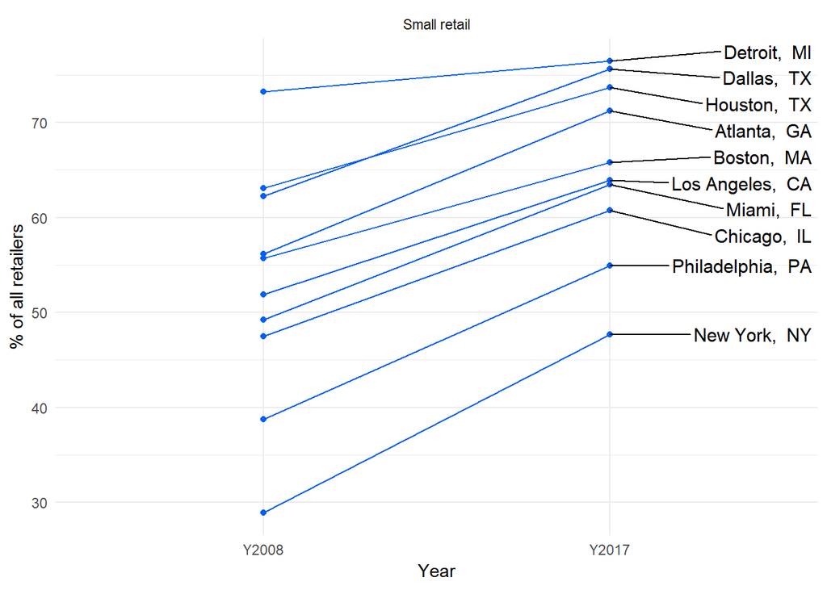

Small retailers as a percentage of all SNAP retailers, 2008 and 2017

```r
dot_plot("Small retail")
```

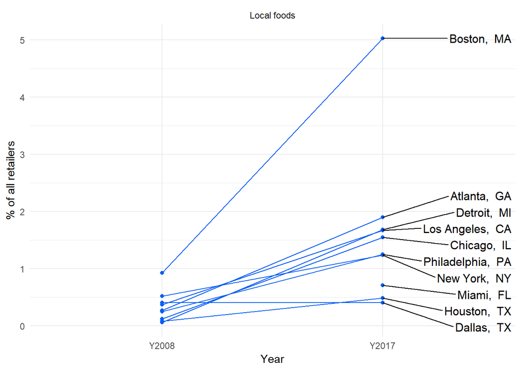

Local foods as a percentage of all SNAP retailers, 2008 and 2017

```r
dot_plot("Local foods")
```

Drilling down deeper into these data, the tables below show the highest and lowest percentages of local food retailers among MSAs with at least 250 retailers in 2017. The top group has several cities from Michigan and Massachusetts, while the bottom group features multiple cities from Texas and other states in the Southeast.

```r
stores_msa_chg1<-stores %>%
  gather(Y2008:Y2017,key="year",value="present") %>%
  filter(present==1 & msa_fips>0) %>%
  group_by(msa_name,msa_short,store_group,year) %>%
  summarise(store_count=n()) %>%
  ungroup() %>%
  group_by(msa_name,msa_short,year)%>%
  mutate(store_count_all=sum(store_count),
         store_pct=round(store_count/store_count_all*100,2)) %>%
  filter(year == "Y2017" & store_group=="Local foods" & store_count_all>250) %>%
  arrange(-store_pct) %>%
  ungroup()

stores_msa_chg1_top20<-stores_msa_chg1[1:20,] %>%
  select(msa_name,store_count,store_count_all,store_pct) %>%
  rename("MSA"=msa_name,
         "Local food retailers"=store_count,
         "All SNAP retailers"=store_count_all,
         "Local food retail rate"=store_pct)

kable(stores_msa_chg1_top20)
```

| MSA | Local food retailers | All SNAP retailers | Local food retail rate |
| --- | --- | --- | --- |
| Urban Honolulu, HI | 50 | 571 | 8.76 |
| Des Moines-West Des Moines, IA | 38 | 515 | 7.38 |
| Santa Rosa, CA | 21 | 289 | 7.27 |
| Flint, MI | 30 | 434 | 6.91 |
| Eugene, OR | 20 | 293 | 6.83 |
| Madison, WI | 24 | 357 | 6.72 |
| Grand Rapids-Wyoming, MI | 45 | 685 | 6.57 |
| Portland-South Portland, ME | 23 | 364 | 6.32 |
| Springfield, MA | 36 | 591 | 6.09 |
| Utica-Rome, NY | 16 | 268 | 5.97 |
| Lexington-Fayette, KY | 22 | 385 | 5.71 |
| Worcester, MA-CT | 35 | 659 | 5.31 |
| Kalamazoo-Portage, MI | 14 | 273 | 5.13 |
| Boston-Cambridge-Newton, MA-NH | 156 | 3099 | 5.03 |
| Huntsville, AL | 16 | 321 | 4.98 |
| Washington-Arlington-Alexandria, DC-VA-MD-WV | 138 | 2834 | 4.87 |
| Asheville, NC | 16 | 340 | 4.71 |
| Portland-Vancouver-Hillsboro, OR-WA | 75 | 1646 | 4.56 |
| Spokane-Spokane Valley, WA | 17 | 381 | 4.46 |
| Birmingham-Hoover, AL | 40 | 944 | 4.24 |

```r
stores_msa_chg1<-stores_msa_chg1 %>%
  arrange(store_pct)

stores_msa_chg1_low20<-stores_msa_chg1[1:20,] %>%
  select(msa_name,store_count,store_count_all,store_pct) %>%
  rename("MSA"=msa_name,
         "Local food retailers"=store_count,
         "All SNAP retailers"=store_count_all,
         "Local food retail rate"=store_pct)

kable(stores_msa_chg1_low20)
```

| MSA | Local food retailers | All SNAP retailers | Local food retail rate |
| --- | --- | --- | --- |
| Corpus Christi, TX | 1 | 368 | 0.27 |
| Baton Rouge, LA | 3 | 762 | 0.39 |
| Dallas-Fort Worth-Arlington, TX | 18 | 4440 | 0.41 |
| Visalia-Porterville, CA | 2 | 433 | 0.46 |
| Houston-The Woodlands-Sugar Land, TX | 21 | 4245 | 0.49 |
| Shreveport-Bossier City, LA | 2 | 362 | 0.55 |
| Gulfport-Biloxi-Pascagoula, MS | 2 | 355 | 0.56 |
| Orlando-Kissimmee-Sanford, FL | 10 | 1771 | 0.56 |
| Brownsville-Harlingen, TX | 2 | 352 | 0.57 |
| Miami-Fort Lauderdale-West Palm Beach, FL | 26 | 3666 | 0.71 |
| Lakeland-Winter Haven, FL | 4 | 545 | 0.73 |
| Stockton-Lodi, CA | 4 | 551 | 0.73 |
| Kingsport-Bristol-Bristol, TN-VA | 2 | 271 | 0.74 |
| Virginia Beach-Norfolk-Newport News, VA-NC | 10 | 1358 | 0.74 |
| McAllen-Edinburg-Mission, TX | 7 | 911 | 0.77 |
| Ocala, FL | 2 | 258 | 0.78 |
| Tampa-St. Petersburg-Clearwater, FL | 19 | 2450 | 0.78 |
| Deltona-Daytona Beach-Ormond Beach, FL | 4 | 491 | 0.81 |
| Las Vegas-Henderson-Paradise, NV | 10 | 1240 | 0.81 |
| Bakersfield, CA | 6 | 720 | 0.83 |

## Potential research directions

Answering these and other questions will require additional work to identify policies and actors affecting enrollment at local, state, and regional scales. Yet, as the brief example of local foods outlets above shows, these data might help publicize initiatives that better support regional food systems and increase access to healthy foods.

## References

Alkon, Alison Hope, and Julian Agyeman. 2011. *Cultivating food justice : race, class, and sustainability*. Cambridge: MIT Press.

Bartfeld, Judith, Craig Gundersen, Timothy Smeeding, and James Ziliak. 2015. *SNAP Matters: How Food Stamps Affect Health and Well-Being*. Stanford: Stanford University Press.

Brones, Anna. 2018. “Food apartheid: the root of the problem with America’s groceries.” https://www.theguardian.com/society/2018/may/15/food-apartheid-food-deserts-racism-inequality-america-karen-washington-interview.

Chrisinger, Benjamin W., Michael J. Kallan, Eliza D. Whiteman, and Amy Hillier. 2018. “Where do U.S. households purchase healthy foods? An analysis of food-at-home purchases across different types of retailers in a nationally representative dataset.” *Preventive Medicine* 112 (November 2017). Elsevier: 15–22. doi:10.1016/j.ypmed.2018.03.015.

Cooksey-Stowers, Kristen, Marlene B Schwartz, and Kelly D Brownell. 2017. “Food Swamps Predict Obesity Rates Better Than Food Deserts in the United States.” *International Journal of Environmental Research and Public Health*, 1–20. doi:10.3390/ijerph14111366.

Cummins, Steven, and Sally Macintyre. 1999. “The location of food stores in urban areas: a case study in Glasgow.” *British Food Journal* 101 (7): 545–53. doi:10.1108/00070709910279027.

Eisenhauer, Elizabeth. 2001. “In poor health: Supermarket redlining and urban nutrition.” *GeoJournal* 53 (2): 125–33. doi:10.1023/A:1015772503007.

Fielding, Jonathan E, and Paul a Simon. 2011. “Food deserts or food swamps?: comment on ‘Fast food restaurants and food stores’.” *Archives of Internal Medicine* 171 (13): 1171–2. doi:10.1001/archinternmed.2011.279.

Ghosh-Dastidar, Madhumita, Gerald Hunter, Rebecca L. Collins, Shannon N. Zenk, Steven Cummins, Robin Beckman, Alvin K. Nugroho, Jennifer C. Sloan, La’Vette Wagner, and Tamara Dubowitz. 2017. “Does opening a supermarket in a food desert change the food environment?” *Health and Place* 46 (October 2016). Elsevier Ltd: 249–56. doi:10.1016/j.healthplace.2017.06.002.

Gritter, Matthew, and Iain MacRobert. 2015. *The Policy and Politics of Food Stamps and SNAP*. New York: Palgrave Pilot.

Hanson, Kenneth. 2010. “The Food Assistance National Input-Output Multiplier (FANIOM) Model and Stimulus Effects of SNAP.” Washington, D.C.: USDA Economic Research Service.

Jackson, Kenneth T. 1987. *Crabgrass frontier: The suburbanization of the United States*. Oxford: Oxford University Press.

Li, Jingjing, and Changjoo Kim. 2017. “Measuring Individuals’ Spatial Access to Healthy Foods by Incorporating Mobility, Time, and Mode: Activity Space Measures.” *The Professional Geographer*. doi:10.1080/00330124.2017.1338591.

Lytle, Leslie A., and Rebeccah L. Sokol. 2017. “Measures of the food environment: A systematic review of the field, 2007–2015.” doi:10.1016/j.healthplace.2016.12.007.

McClintock, Nathan. 2011. “From Industrial Garden to Food Desert: Demarcated Devaluation in the Flatlands of Oakland, California.” In *Cultivating Food Justice: Race, Class, and Sustainability*, edited by Alison Alkon and Julian Agyeman, 135–79. Cambridge MA: MIT Press.

Moran, Rachel L. 2011. “Consuming Relief: Food Stamps and the New Welfare of the New Deal.” *Journal of American History* 97 (4): 1001–22. doi:10.1093/jahist/jaq067.

Office of Community Services. 2011. “Healthy Food Financing Initiative.” http://www.acf.hhs.gov/programs/ocs/programs/community-economic-development/healthy-food-financing.

Shannon, Jerry. 2014. “Food deserts: governing obesity in the neoliberal city.” *Progress in Human Geography* 38 (2): 248–66. doi:10.1177/0309132513484378.

———. 2016. “Beyond the Supermarket Solution: Linking Food Deserts, Neighborhood Context, and Everyday Mobility.” *Annals of the American Association of Geographers* 106 (1): 186–202. doi:10.1080/00045608.2015.1095059.

Shannon, Jerry, Grace Bagwell-Adams, Sarah Shannon, Jung Sun Lee, and Yangjiaxin Wei. 2018. “The mobility of food retailers: How proximity to SNAP authorized food retailers changed in Atlanta during the Great Recession.” *Social Science & Medicine* 209: 125–35. doi:https://doi.org/10.1016/j.socscimed.2018.05.046.

U.S. Dept. of Agriculture. 2018. “Supplemental Nutrition Assistance Program Participation and Costs.” https://fns-prod.azureedge.net/sites/default/files/pd/SNAPsummary.pdf.

USDA Economic Research Service. 2014. “Food Access Research Atlas - Documentation.” http://www.ers.usda.gov/data-products/food-access-research-atlas/documentation.aspx{\#}definitions.

Walker, Renee E, Christopher R Keane, and Jessica G Burke. 2010. “Disparities and access to healthy food in the United States: A review of food deserts literature.” *Health & Place* 16 (5): 876–84. doi:10.1016/j.healthplace.2010.04.013.

Widener, Michael J., and Jerry Shannon. 2014. “When are food deserts? Integrating time into research on food accessibility.” *Health & Place* 30 (November). Elsevier: 1–3. doi:10.1016/j.healthplace.2014.07.011.

Wrigley, Neil. 2002. “’Food Deserts’ in British Cities: Policy Context and Research Priorities.” *Urban Studies* 39 (11): 2029–40. doi:10.1080/0042098022000011344.

Zhang, Mengyao, and Debarchana Ghosh. 2016. “Spatial Supermarket Redlining and Neighborhood Vulnerability: A Case Study of Hartford, Connecticut.” *Transactions in GIS* 20 (1): 79–100. doi:10.1111/tgis.12142.